# LMM: Introduction

2018-05-15

## Mixed-effects models

- 4.0 Introduction to LMM
- 4.1 Random effects
- 4.2 Solving LM problems using LMM
- 4.3 A showcase of some useful applications
- 4.4 Introduction to GLMM
- 4.5 More complex mixed models

## You will learn in this session

- why you may need linear mixed-effects models
- what mixed models are
- how to use `lme4` and `spaMM` to fit mixed models
- how to fit a simple mixed models by hand in a few lines of code
- what BLUPs are
- how to make predictions at two different levels
- how to test effects using parametric bootstraps
- how to check assumptions for a linear mixed-effects model

## Introduction

## Why Linear Mixed-effects Models?

### Goal:

To study, or to account for, unobservable sources of heterogeneity between observations.

The main sources of heterogeneity considered by mixed-effects models are:

- origin (in its widest sense)
- time
- space

## The linear mixed-effects model

### Definition

- a LMM is a specific linear model for which, given the design matrix \(\mathbf{X}\), the responses (\(\mathbf{Y}\)) are no longer independent, but where the correlations can be described in terms of a random effect, i.e. a random variable that is not included in the predictor variables

## Mathematical notation of LM

LM, which we have seen before:

\(\mathbf{Y} = \mathbf{X} \beta + \epsilon\)

\[ \begin{bmatrix} y_1 \\ y_2 \\ y_3 \\ \vdots \\ y_n \end{bmatrix} = \begin{bmatrix} 1 & x_{1,1} & x_{1,2} & \dots & x_{1,p} \\ 1 & x_{2,1} & x_{2,2} & \dots & x_{2,p} \\ 1 & x_{3,1} & x_{3,2} & \dots & x_{3,p} \\ \vdots & \vdots & \vdots & \ddots & \vdots \\ 1 & x_{n,1} & x_{n,2} & \dots & x_{n,p} \end{bmatrix} \begin{bmatrix} \beta_0 \\ \beta_1 \\ \beta_2 \\ \vdots \\ \beta_p \end{bmatrix}+ \begin{bmatrix} \epsilon_1 \\ \epsilon_2 \\ \epsilon_3 \\ \vdots \\ \epsilon_n \end{bmatrix} \] with, \[ \epsilon \sim \mathcal{N}\left(0, \begin{bmatrix} \sigma^2 & 0 & 0 & \dots & 0 \\ 0 & \sigma^2 & 0 & \dots & 0 \\ 0 & 0 & \sigma^2 & \dots & 0 \\ \vdots & \vdots & \vdots & \ddots & \vdots \\ 0 & 0 & 0 & \dots & \sigma^2 \end{bmatrix}\right) \]

## Mathematical notation of LMM

LMM with one random factor with \(q\) levels:

\(\mathbf{Y} = \mathbf{X} \beta + \mathbf{Z}b + \epsilon\)

\[ \begin{bmatrix} y_1 \\ y_2 \\ y_3 \\ \vdots \\ y_n \end{bmatrix} = \begin{bmatrix} 1 & x_{1,1} & x_{1,2} & \dots & x_{1,p} \\ 1 & x_{2,1} & x_{2,2} & \dots & x_{2,p} \\ 1 & x_{3,1} & x_{3,2} & \dots & x_{3,p} \\ \vdots & \vdots & \vdots & \ddots & \vdots \\ 1 & x_{n,1} & x_{n,2} & \dots & x_{n,p} \end{bmatrix} \begin{bmatrix} \beta_0 \\ \beta_1 \\ \beta_2 \\ \vdots \\ \beta_p \end{bmatrix}+ \begin{bmatrix} z_{1,1} & z_{1,2} & z_{1,3} & \dots & z_{1,q} \\ z_{2,1} & z_{2,2} & z_{2,3} & \dots & z_{2,q} \\ z_{3,1} & z_{3,2} & z_{3,3} & \dots & z_{3,q} \\ \vdots & \vdots & \vdots & \ddots & \vdots \\ z_{n,1} & z_{n,2} & z_{n,3} & \dots & z_{n,q} \\ \end{bmatrix} \begin{bmatrix} b_1 \\ b_2 \\ b_3 \\ \vdots \\ b_q \end{bmatrix}+ \begin{bmatrix} \epsilon_1 \\ \epsilon_2 \\ \epsilon_3 \\ \vdots \\ \epsilon_n \end{bmatrix} \] with, \[ b \sim \mathcal{N}\left(0, \begin{bmatrix} c_{1,1} & c_{1,2} & c_{1,3} & \dots & c_{1,q} \\ c_{2,1} & c_{2,2} & c_{2,3} & \dots & c_{2,q} \\ c_{3,1} & c_{3,2} & c_{3,3} & \dots & c_{3,q} \\ \vdots & \vdots & \vdots & \ddots & \vdots \\ c_{q,1} & c_{q,2} & c_{q,3} & \dots & c_{q,q} \\ \end{bmatrix}\right) \text{& } \epsilon \sim \mathcal{N}\left(0, \begin{bmatrix} \phi & 0 & 0 & \dots & 0 \\ 0 & \phi & 0 & \dots & 0 \\ 0 & 0 & \phi & \dots & 0 \\ \vdots & \vdots & \vdots & \ddots & \vdots \\ 0 & 0 & 0 & \dots & \phi \end{bmatrix}\right) \]

with \(\text{E}(b) = 0\), \(\text{Cov}(b) = \mathbf{C}\), which is symmetrical (\(c_{i, j} = c_{j, i}\)). Also, \(\text{Cov}(b, \epsilon) = 0\).

## Mathematical notation of LMM

LMM with one random factor with \(q\) levels:

\(\mathbf{Y} = \mathbf{X} \beta + \mathbf{Z}b + \epsilon\)

\[ \begin{bmatrix} y_1 \\ y_2 \\ y_3 \\ \vdots \\ y_n \end{bmatrix} = \begin{bmatrix} 1 & x_{1,1} & x_{1,2} & \dots & x_{1,p} \\ 1 & x_{2,1} & x_{2,2} & \dots & x_{2,p} \\ 1 & x_{3,1} & x_{3,2} & \dots & x_{3,p} \\ \vdots & \vdots & \vdots & \ddots & \vdots \\ 1 & x_{n,1} & x_{n,2} & \dots & x_{n,p} \end{bmatrix} \begin{bmatrix} \beta_0 \\ \beta_1 \\ \beta_2 \\ \vdots \\ \beta_p \end{bmatrix}+ \begin{bmatrix} z_{1,1} & z_{1,2} & z_{1,3} & \dots & z_{1,q} \\ z_{2,1} & z_{2,2} & z_{2,3} & \dots & z_{2,q} \\ z_{3,1} & z_{3,2} & z_{3,3} & \dots & z_{3,q} \\ \vdots & \vdots & \vdots & \ddots & \vdots \\ z_{n,1} & z_{n,2} & z_{n,3} & \dots & z_{n,q} \\ \end{bmatrix} \begin{bmatrix} b_1 \\ b_2 \\ b_3 \\ \vdots \\ b_q \end{bmatrix}+ \begin{bmatrix} \epsilon_1 \\ \epsilon_2 \\ \epsilon_3 \\ \vdots \\ \epsilon_n \end{bmatrix} \] and often, \[ b \sim \mathcal{N}\left(0, \begin{bmatrix} \lambda & 0 & 0 & \dots & 0 \\ 0 & \lambda & 0 & \dots & 0 \\ 0 & 0 & \lambda & \dots & 0 \\ \vdots & \vdots & \vdots & \ddots & \vdots \\ 0 & 0 & 0 & \dots & \lambda \\ \end{bmatrix}\right) \text{& } \epsilon \sim \mathcal{N}\left(0, \begin{bmatrix} \phi & 0 & 0 & \dots & 0 \\ 0 & \phi & 0 & \dots & 0 \\ 0 & 0 & \phi & \dots & 0 \\ \vdots & \vdots & \vdots & \ddots & \vdots \\ 0 & 0 & 0 & \dots & \phi \end{bmatrix}\right) \]

Note: the dimensions of the matrices differ: \(q \times q\) vs \(n \times n\)

## Fitting procedure

## A simple simulation function

```r
simulate_Mix <- function(intercept, slope, n, group_nb, var.rand, var.error){
  data <- data.frame(intercept = intercept, slope = slope, x = runif(n))
  group_compo <- rmultinom(n = 1, size = n, prob = c(rep(1/group_nb, group_nb)))
  data$group <- factor(rep(paste("group", 1:group_nb, sep = "_"), group_compo))
  data$b <- rep(rnorm(group_nb, mean = 0, sd = sqrt(var.rand)), group_compo)
  data$error <- rnorm(n, mean = 0, sd = sqrt(var.error))
  data$y <- data$intercept + data$slope*data$x + data$b + data$error
  return(data)
}

set.seed(1)
Aliens <- simulate_Mix(intercept = 50, slope = 1.5, n = 30, group_nb = 10, var.rand = 2, var.error = 0.5)
```

## Our toy dataset

```r
Aliens
```

```
##    intercept slope          x    group           b       error        y
## 1         50   1.5 0.26550866  group_1 -0.31716268 -0.16666970 49.91443
## 2         50   1.5 0.37212390  group_1 -0.31716268 -0.38387997 49.85714
## 3         50   1.5 0.57285336  group_1 -0.31716268 -0.30639666 50.23572
## 4         50   1.5 0.90820779  group_2  0.53371804 -0.45924581 51.43678
## 5         50   1.5 0.20168193  group_2  0.53371804  0.51389038 51.35013
## 6         50   1.5 0.89838968  group_2  0.53371804  0.81452461 52.69583
## 7         50   1.5 0.94467527  group_3  0.18856609  0.70156332 52.30714
## 8         50   1.5 0.66079779  group_3  0.18856609 -0.30371163 50.87605
## 9         50   1.5 0.62911404  group_3  0.18856609  0.87561323 52.00785
## 10        50   1.5 0.06178627  group_4  1.13729571 -0.19752765 51.03245
## 11        50   1.5 0.20597457  group_4  1.13729571  1.24302520 52.68928
## 12        50   1.5 0.17655675  group_5 -0.08076117  0.39650736 50.58058
## 13        50   1.5 0.68702285  group_5 -0.08076117 -0.32016662 50.62961
## 14        50   1.5 0.38410372  group_5 -0.08076117 -0.58834346 49.90705
```

[output cut: 16 more lines]

## Fitting the model with `lme4`

```r
library(lme4)
(mod_lme4 <- lmer(y ~ x + (1|group), data = Aliens, REML = FALSE))
```

```
## Linear mixed model fit by maximum likelihood  ['lmerMod']
## Formula: y ~ x + (1 | group)
##    Data: Aliens
##      AIC      BIC   logLik deviance df.resid
##  91.3162  96.9210 -41.6581  83.3162       26
## Random effects:
##  Groups   Name        Std.Dev.
##  group    (Intercept) 1.1627
##  Residual             0.6666
## Number of obs: 30, groups:  group, 10
## Fixed Effects:
## (Intercept)            x
##      50.097        1.408
```

```r
c(var.group = as.numeric(attr(VarCorr(mod_lme4)$group, "stddev")^2),
  var.error = as.numeric(attr(VarCorr(mod_lme4), "sc")^2))  ## note: those are biased estimates (ML not REML)
```

```
## var.group var.error
## 1.3518290 0.4443361
```

## Fitting the model with `spaMM`

```r
library(spaMM)
(mod_spaMM <- fitme(y ~ x + (1|group), data = Aliens, method = "ML"))
```

```
## formula: y ~ x + (1 | group)
## ML: Estimation of lambda and phi by ML.
##     Estimation of fixed effects by ML.
## Family: gaussian ( link = identity )
##  ------------ Fixed effects (beta) ------------
##             Estimate Cond. SE t-value
## (Intercept)   50.097   0.4706 106.453
## x              1.408   0.5405   2.606
##  --------------- Random effects ---------------
## Family: gaussian ( link = identity )
##            --- Variance parameters ('lambda'):
## lambda = var(u) for u ~ Gaussian;
##    group  :  1.352
##              --- Coefficients for log(lambda):
##  Group        Term Estimate Cond.SE
##  group (Intercept)   0.3015  0.4751
## # of obs: 30; # of groups: group, 10
##  ------------- Residual variance  -------------
## Coefficients for log(phi) ~ 1 :
##             Estimate Cond. SE
## (Intercept)  -0.8112   0.3076
## Estimate of phi=residual var:  0.4443
##  ------------- Likelihood values  -------------
##                         logLik
## p_v(h) (marginal L): -41.65809
```

## Functions for fitting the mixed model numerically

```r
log_lik_b_prod <- function(param, data, scale = 1){
  log_lik_vec <- sapply(levels(data$group), function(level) {
    log(integrate(lik_b, -Inf, Inf, level = level, intercept = param[1], slope = param[2],
                  var.rand = param[3], var.error = param[4], data = data)$value)})
  return(scale * sum(log_lik_vec))
}
```

```r
lik_b <- function(b.vec, level, intercept, slope, var.rand, var.error, data, scale = 1){
  lik <- sapply(b.vec, function(b){
    sub_data <- data[which(data$group == level), ]
    sub_data$pred <- intercept + slope*sub_data$x + b
    sub_data$conditional.density <- dnorm(sub_data$y, mean = sub_data$pred, sd = sqrt(var.error))
    return(dnorm(b, mean = 0, sd = sqrt(var.rand)) * prod(sub_data$conditional.density))
  })
  return(scale * lik)
}
```

## Testing the functions

Let's test the function under fixed parameter values:

```r
log_lik_b_prod(param = c(50, 1.5, 2, 0.5), data = Aliens) ## test functions above
```

```
## [1] -42.04859
```

```r
mod_constr <- fitme(y ~ 0 + (1|group) + offset(50 + 1.5*x), data = Aliens, fixed = list(lambda = 2, phi = 0.5))
logLik(mod_constr)
```

```
##       p_v
## -42.04859
```

## Fitting the mixed model numerically

```r
bad_mod <- lm(y ~ x + group, data = Aliens)
```

```r
(init_values <- c(bad_mod$coefficients[1], bad_mod$coefficients[2],
                  var.group = var(bad_mod$coefficients[-c(1:2)]),
                  var.error = deviance(bad_mod) / bad_mod$df.residual))
```

```
## (Intercept)           x   var.group   var.error
##  49.5240350   1.1856310   1.9457554   0.4624936
```

```r
system.time(
  opt <-  nloptr::nloptr(x0 = init_values, eval_f = log_lik_b_prod, data = Aliens, scale = -1,
                         lb = 0.5*init_values, ub = 2*init_values,
                         opts = list(algorithm = "NLOPT_LN_BOBYQA", xtol_rel = 1.0e-4, maxeval = -1))
)
```

```
##    user  system elapsed
##  38.249   0.164  38.970
```

## Fitting the mixed model numerically

```r
estimates <- rbind(opt$solution, as.numeric(c(mod_spaMM$fixef, mod_spaMM$lambda, mod_spaMM$phi)))
colnames(estimates) <- c("intercept", "slope", "var.group", "var.error")
rownames(estimates) <- c("numeric", "spaMM")
estimates
```

```
##         intercept    slope var.group var.error
## numeric  50.09752 1.408000  1.351919 0.4443761
## spaMM    50.09746 1.408232  1.351828 0.4443367
```

```r
c(logLik.num = -1 * opt$objective, logLik.spaMM = logLik(mod_spaMM)[[1]])
```

```
##   logLik.num logLik.spaMM
##    -41.65809    -41.65809
```

## The estimation of random effects

### We estimate the realized values of the random variable:

```r
ranef_alex <- sapply(levels(Aliens$group), function(group) {
  nloptr::nloptr(x0 = 0, lik_b, level = group, intercept = opt$solution[1],
                 slope = opt$solution[2], var.rand = opt$solution[3],
                 var.error = opt$solution[4], data = Aliens, scale = -1,
                 lb = -4*sqrt(opt$solution[3]), ub = 4*sqrt(opt$solution[3]),
                 opts = list(algorithm = "NLOPT_LN_BOBYQA", xtol_rel = 1.0e-4, maxeval = -1))$solution})

rbind(ranef_alex,
      ranef_lme4 = as.numeric(t(lme4::ranef(mod_lme4)[[1]])),
      ranef_spaMM = as.numeric(unlist(ranef(mod_spaMM))))
```

```
##                group_1  group_10   group_2   group_3  group_4    group_5   group_6  group_7   group_8   group_9
## ranef_alex  -0.5977224 -1.038178 0.7097413 0.5263846 1.352547 -0.5161482 0.7019793 1.727150 -1.223389 -1.641877
## ranef_lme4  -0.5977558 -1.038252 0.7096554 0.5262825 1.352575 -0.5162039 0.7018877 1.727069 -1.223375 -1.641882
## ranef_spaMM -0.5977555 -1.038252 0.7096549 0.5262820 1.352574 -0.5162039 0.7018872 1.727068 -1.223373 -1.641882
```

## Best Linear Unbiased Predictions

- The numbers we obtained with `ranef` are BLUPs of the random effects.
- Even if BLUPs can be estimated, they are not parameters of the statistical model!!!
- BLUPs can be computed using ML or REML (REML is best when BLUPs are not added to fitted values, unclear otherwise)

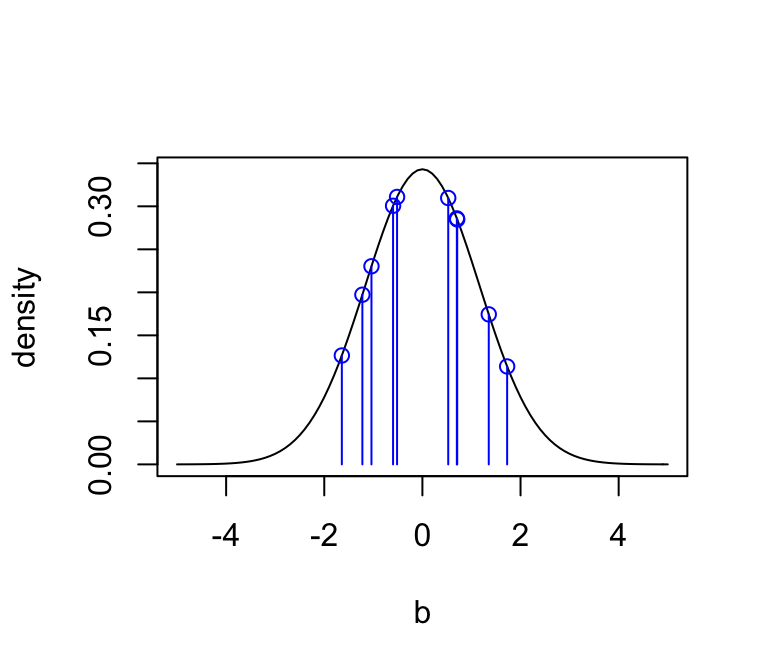

```r
curve(dnorm(x, mean = 0, sd = sqrt(estimates[1, "var.group"])), -5, 5, ylab = "density", xlab = "b")
points(dnorm(ranef_alex, mean = 0, sd = sqrt(estimates[1, "var.group"])) ~ ranef_alex, col = "blue", type = "h")
points(dnorm(ranef_alex, mean = 0, sd = sqrt(estimates[1, "var.group"])) ~ ranef_alex, col = "blue")
```

## A simple example of LMM

## The `nlme::Oats` dataset

```r
data("Oats", package = "nlme")
Oats2 <- as.data.frame(Oats)
Oats2$Block <- factor(Oats2$Block, ordered = FALSE, levels = sort(levels(Oats2$Block)))
head(Oats2)
```

```
##   Block     Variety nitro yield
## 1     I     Victory   0.0   111
## 2     I     Victory   0.2   130
## 3     I     Victory   0.4   157
## 4     I     Victory   0.6   174
## 5     I Golden Rain   0.0   117
## 6     I Golden Rain   0.2   114
```

```r
str(Oats2)
```

```
## 'data.frame':    72 obs. of  4 variables:
##  $ Block  : Factor w/ 6 levels "I","II","III",..: 1 1 1 1 1 1 1 1 1 1 ...
##  $ Variety: Factor w/ 3 levels "Golden Rain",..: 3 3 3 3 1 1 1 1 2 2 ...
##  $ nitro  : num  0 0.2 0.4 0.6 0 0.2 0.4 0.6 0 0.2 ...
##  $ yield  : num  111 130 157 174 117 114 161 141 105 140 ...
```

## The `nlme::Oats` dataset

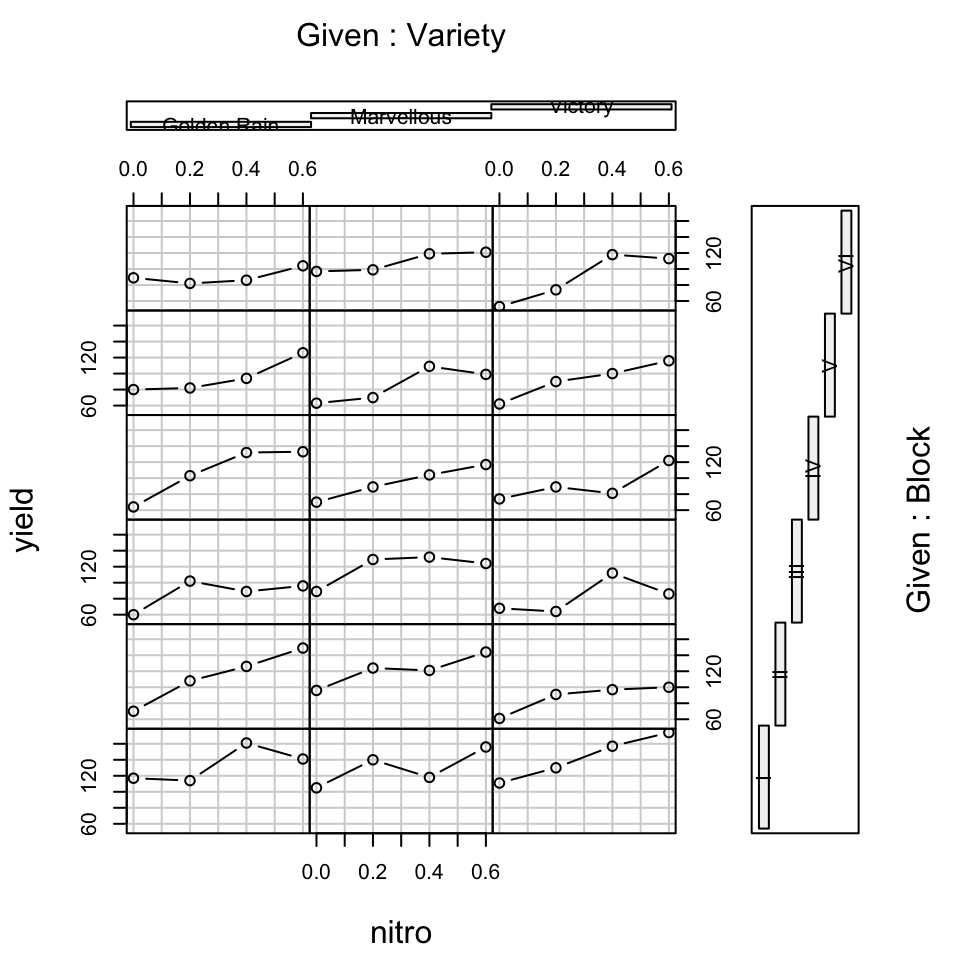

```r
coplot(yield ~ nitro | Variety + Block, data = Oats2, type = "b")
```

## LMM using `lme4`

```r
(mod_lmm_lme4 <- lmer(yield ~ nitro + Variety + (1|Block), data = Oats2, REML = FALSE))
```

```
## Linear mixed model fit by maximum likelihood  ['lmerMod']
## Formula: yield ~ nitro + Variety + (1 | Block)
##    Data: Oats2
##       AIC       BIC    logLik  deviance  df.resid
##  620.7978  634.4578 -304.3989  608.7978        66
## Random effects:
##  Groups   Name        Std.Dev.
##  Block    (Intercept) 14.21
##  Residual             14.97
## Number of obs: 72, groups:  Block, 6
## Fixed Effects:
##       (Intercept)              nitro  VarietyMarvellous     VarietyVictory
##            82.400             73.667              5.292             -6.875
```

## LMM using `lme4`

```r
head(mod_lmm_lme4@pp$X)  ## X
```

```
##   (Intercept) nitro VarietyMarvellous VarietyVictory
## 1           1   0.0                 0              1
## 2           1   0.2                 0              1
## 3           1   0.4                 0              1
## 4           1   0.6                 0              1
## 5           1   0.0                 0              0
## 6           1   0.2                 0              0
```

```r
mod_lmm_lme4@beta  ## beta estimates
```

```
## [1] 82.400000 73.666667  5.291667 -6.875000
```

```r
c(var.group = as.numeric(attr(VarCorr(mod_lmm_lme4)$Block, "stddev")^2),
  var.error = as.numeric(attr(VarCorr(mod_lmm_lme4), "sc")^2))  ## lambda and phi estimates
```

```
## var.group var.error
##  201.8183  224.0592
```

## LMM using `lme4`

```r
head(t(mod_lmm_lme4@pp$Zt))  ## Z
```

```
## 6 x 6 sparse Matrix of class "dgCMatrix"
##   I II III IV V VI
## 1 1  .   .  . .  .
## 2 1  .   .  . .  .
## 3 1  .   .  . .  .
## 4 1  .   .  . .  .
## 5 1  .   .  . .  .
## 6 1  .   .  . .  .
```

```r
as.matrix(mod_lmm_lme4@pp$Zt)
```

```
##     1 2 3 4 5 6 7 8 9 10 11 12 13 14 15 16 17 18 19 20 21 22 23 24 25 26 27 28 29 30 31 32 33 34 35 36 37 38 39 40 41
## I   1 1 1 1 1 1 1 1 1  1  1  1  0  0  0  0  0  0  0  0  0  0  0  0  0  0  0  0  0  0  0  0  0  0  0  0  0  0  0  0  0
## II  0 0 0 0 0 0 0 0 0  0  0  0  1  1  1  1  1  1  1  1  1  1  1  1  0  0  0  0  0  0  0  0  0  0  0  0  0  0  0  0  0
## III 0 0 0 0 0 0 0 0 0  0  0  0  0  0  0  0  0  0  0  0  0  0  0  0  1  1  1  1  1  1  1  1  1  1  1  1  0  0  0  0  0
## IV  0 0 0 0 0 0 0 0 0  0  0  0  0  0  0  0  0  0  0  0  0  0  0  0  0  0  0  0  0  0  0  0  0  0  0  0  1  1  1  1  1
## V   0 0 0 0 0 0 0 0 0  0  0  0  0  0  0  0  0  0  0  0  0  0  0  0  0  0  0  0  0  0  0  0  0  0  0  0  0  0  0  0  0
## VI  0 0 0 0 0 0 0 0 0  0  0  0  0  0  0  0  0  0  0  0  0  0  0  0  0  0  0  0  0  0  0  0  0  0  0  0  0  0  0  0  0
##     42 43 44 45 46 47 48 49 50 51 52 53 54 55 56 57 58 59 60 61 62 63 64 65 66 67 68 69 70 71 72
## I    0  0  0  0  0  0  0  0  0  0  0  0  0  0  0  0  0  0  0  0  0  0  0  0  0  0  0  0  0  0  0
## II   0  0  0  0  0  0  0  0  0  0  0  0  0  0  0  0  0  0  0  0  0  0  0  0  0  0  0  0  0  0  0
## III  0  0  0  0  0  0  0  0  0  0  0  0  0  0  0  0  0  0  0  0  0  0  0  0  0  0  0  0  0  0  0
## IV   1  1  1  1  1  1  1  0  0  0  0  0  0  0  0  0  0  0  0  0  0  0  0  0  0  0  0  0  0  0  0
## V    0  0  0  0  0  0  0  1  1  1  1  1  1  1  1  1  1  1  1  0  0  0  0  0  0  0  0  0  0  0  0
## VI   0  0  0  0  0  0  0  0  0  0  0  0  0  0  0  0  0  0  0  1  1  1  1  1  1  1  1  1  1  1  1
```

## LMM using `lme4`

```r
head(t(mod_lmm_lme4@pp$Zt))  ## Z
```

```
## 6 x 6 sparse Matrix of class "dgCMatrix"
##   I II III IV V VI
## 1 1  .   .  . .  .
## 2 1  .   .  . .  .
## 3 1  .   .  . .  .
## 4 1  .   .  . .  .
## 5 1  .   .  . .  .
## 6 1  .   .  . .  .
```

```r
crossprod(t(as.matrix(mod_lmm_lme4@pp$Zt)))
```

```
##      I II III IV  V VI
## I   12  0   0  0  0  0
## II   0 12   0  0  0  0
## III  0  0  12  0  0  0
## IV   0  0   0 12  0  0
## V    0  0   0  0 12  0
## VI   0  0   0  0  0 12
```

## LMM using `lme4`

```r
lme4::ranef(mod_lmm_lme4)  ## b estimates
```

```
## $Block
##     (Intercept)
## I     28.705380
## II     3.000208
## III   -7.373392
## IV    -5.313928
## V    -11.949981
## VI    -7.068287
```

## LMM using `spaMM`

```r
(mod_lmm_spaMM <- fitme(yield ~ nitro + Variety + (1|Block), data = Oats2))
```

```
## formula: yield ~ nitro + Variety + (1 | Block)
## ML: Estimation of lambda and phi by ML.
##     Estimation of fixed effects by ML.
## Family: gaussian ( link = identity )
##  ------------ Fixed effects (beta) ------------
##                   Estimate Cond. SE t-value
## (Intercept)         82.400    6.969  11.823
## nitro               73.667    7.889   9.338
## VarietyMarvellous    5.292    4.321   1.225
## VarietyVictory      -6.875    4.321  -1.591
##  --------------- Random effects ---------------
## Family: gaussian ( link = identity )
##            --- Variance parameters ('lambda'):
## lambda = var(u) for u ~ Gaussian;
##    Block  :  201.8
##              --- Coefficients for log(lambda):
##  Group        Term Estimate Cond.SE
##  Block (Intercept)    5.307  0.6035
## # of obs: 72; # of groups: Block, 6
##  ------------- Residual variance  -------------
## Coefficients for log(phi) ~ 1 :
##             Estimate Cond. SE
## (Intercept)    5.412   0.1734
## Estimate of phi=residual var:  224.1
##  ------------- Likelihood values  -------------
##                         logLik
## p_v(h) (marginal L): -304.3989
```

## LMM using `spaMM`

```r
head(mod_lmm_spaMM$X.pv)  ## X
```

```
##   (Intercept) nitro VarietyMarvellous VarietyVictory
## 1           1   0.0                 0              1
## 2           1   0.2                 0              1
## 3           1   0.4                 0              1
## 4           1   0.6                 0              1
## 5           1   0.0                 0              0
## 6           1   0.2                 0              0
```

```r
mod_lmm_spaMM$fixef  ## beta estimates
```

```
##       (Intercept)             nitro VarietyMarvellous    VarietyVictory
##         82.400000         73.666667          5.291667         -6.875000
```

```r
as.numeric(c(mod_lmm_spaMM$lambda, mod_lmm_spaMM$phi))  ## lambda and phi estimates
```

```
## [1] 201.8183 224.0592
```

## LMM using `spaMM`

```r
head(mod_lmm_spaMM$ZAlist[[1]])  ## Z
```

```
## 6 x 6 sparse Matrix of class "dgCMatrix"
##      I II III IV V VI
## [1,] 1  .   .  . .  .
## [2,] 1  .   .  . .  .
## [3,] 1  .   .  . .  .
## [4,] 1  .   .  . .  .
## [5,] 1  .   .  . .  .
## [6,] 1  .   .  . .  .
```

```r
crossprod(mod_lmm_spaMM$ZAlist[[1]])
```

```
## 6 x 6 sparse Matrix of class "dsCMatrix"
##      I II III IV  V VI
## I   12  .   .  .  .  .
## II   . 12   .  .  .  .
## III  .  .  12  .  .  .
## IV   .  .   . 12  .  .
## V    .  .   .  . 12  .
## VI   .  .   .  .  . 12
```

## LMM using `spaMM`

```r
ranef(mod_lmm_spaMM)  ## b estimates
```

```
## $`( 1 | Block )`
##          I         II        III         IV          V         VI
##  28.705376   3.000208  -7.373392  -5.313927 -11.949979  -7.068286
##
## attr(,"class")
## [1] "list"  "ranef"
```

## Predictions

## Predictions with LM

```r
mod_lm <- lm(yield ~ nitro + Variety + Block, data = Oats2)
data.for.pred <- expand.grid(nitro = 0.3, Variety = "Victory", Block = levels(Oats2$Block))
(p <- predict(mod_lm, newdata = data.for.pred, interval = "confidence", se.fit = TRUE))
```

```
## $fit
##         fit       lwr       upr
## 1 128.98611 118.78068 139.19154
## 2 100.90278  90.69735 111.10821
## 3  89.56944  79.36401  99.77487
## 4  91.81944  81.61401 102.02487
## 5  84.56944  74.36401  94.77487
## 6  89.90278  79.69735 100.10821
##
## $se.fit
##        1        2        3        4        5        6
## 5.106952 5.106952 5.106952 5.106952 5.106952 5.106952
##
## $df
## [1] 63
##
## $residual.scale
## [1] 15.32086
```

## Predictions with LM

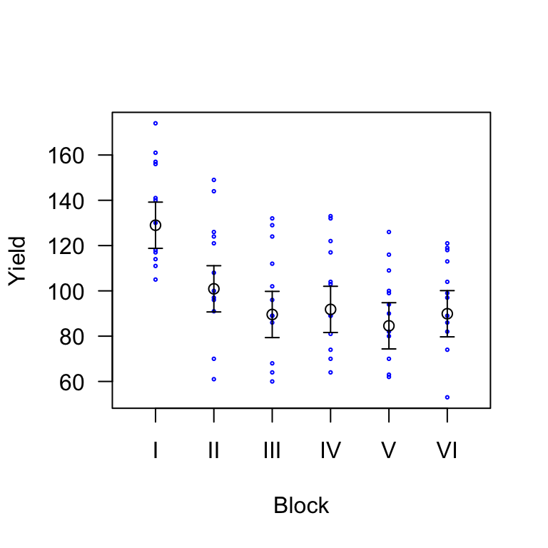

```r
plot(Oats2$yield ~ unclass(Oats2$Block), axes = FALSE, ylab = "Yield", xlab = "Block",
     xlim = c(0.5, length(levels(Oats2$Block)) + 0.5), col = "blue", cex = 0.3)
points(p$fit[, "fit"] ~ I(1:length(levels(Oats2$Block))))
arrows(x0 = 1:length(levels(Oats2$Block)), y0 = p$fit[, "lwr"], y1 = p$fit[, "upr"],
       code = 3, angle = 90, length = 0.05)
axis(1, at = 1:length(levels(Oats2$Block)), labels = levels(Oats2$Block)); axis(2, las = 1); box()
```

## Marginal predictions using `lme4`

### Predictions averaged over the random variable:

```r
data.for.pred <- expand.grid(nitro = 0.3, Variety = "Victory", Block = "new")
p1 <- predict(mod_lmm_lme4, newdata = data.for.pred, re.form = NA)
X <- matrix(c(1, 0.3, 0, 1), nrow = 1)
se.fit <- sqrt(X %*% vcov(mod_lmm_lme4) %*% t(X))
se.rand <- attr(VarCorr(mod_lmm_lme4)$Block, "stddev")
(se.predVar <- as.numeric(sqrt(se.fit^2 + se.rand^2)))
```

```
## [1] 15.64578
```

```r
lwr <- as.numeric(p1 + qnorm(0.025) * se.predVar)
upr <- as.numeric(p1 + qnorm(0.975) * se.predVar)
c(fit = as.numeric(p1), lwr = lwr, upr = upr)  ## Wald CI for prediction
```

```
##       fit       lwr       upr
##  97.62500  66.95983 128.29017
```

## Marginal predictions using `spaMM`

### Predictions averaged over the random variable:

```r
data.for.pred <- expand.grid(nitro = 0.3, Variety = "Victory", Block = "new")
p2 <- predict(mod_lmm_spaMM, newdata = data.for.pred, intervals = "predVar")
sqrt(attr(p2, "predVar"))  ## se.predVar
```

```
##        1
## 15.64578
```

```r
c(fit = p2, attr(p2, "intervals"))
```

```
##       fit
##  97.62500  66.95983 128.29017
```

## Conditional predictions using `spaMM`

### Predictions conditional on the random variable (\(\mathbf{X}\widehat{\beta}+\mathbf{Z}\widehat{b}\)):

```r
data.for.pred <- expand.grid(nitro = 0.3, Variety = "Victory", Block = levels(Oats2$Block))
p3 <- predict(mod_lmm_spaMM, newdata = data.for.pred, intervals = "predVar")
sqrt(attr(p3, "predVar"))  ## se.predVar
```

```
##        1        2        3        4        5        6
## 5.112977 4.858585 4.873095 4.864743 4.901256 4.871688
```

```r
cbind(p3, attr(p3, "intervals"))
```

```
##             predVar_0.025 predVar_0.975
## 1 126.33038     116.30913     136.35163
## 2 100.62521      91.10256     110.14786
## 3  90.25161      80.70052      99.80270
## 4  92.31107      82.77635     101.84579
## 5  85.67502      76.06874      95.28131
## 6  90.55671      81.00838     100.10505
```

## Conditional predictions using `lme4 + merTools`

### Predictions conditional on the random variable (\(\mathbf{X}\widehat{\beta}+\mathbf{Z}\widehat{b}\)):

```r
data.for.pred <- expand.grid(nitro = 0.3, Variety = "Victory", Block = levels(Oats2$Block))
library(merTools)
(p4 <- predictInterval(mod_lmm_lme4, newdata = data.for.pred, include.resid.var = FALSE))
```

```
##         fit       upr       lwr
## 1 126.19724 135.71730 115.87171
## 2 100.45554 110.67738  90.70890
## 3  89.91994  99.99701  79.67400
## 4  92.03807 101.56409  82.03344
## 5  85.30636  95.32601  75.98288
## 6  90.14716  99.94953  80.62247
```

Note 1: `lme4` does not compute assymptotic confidence intervals, which is why we use `merTools`.

Note 2: `merTools` uses simulation so results differ slightly each time you run the function.

## Comparing predictions from LM and LMM

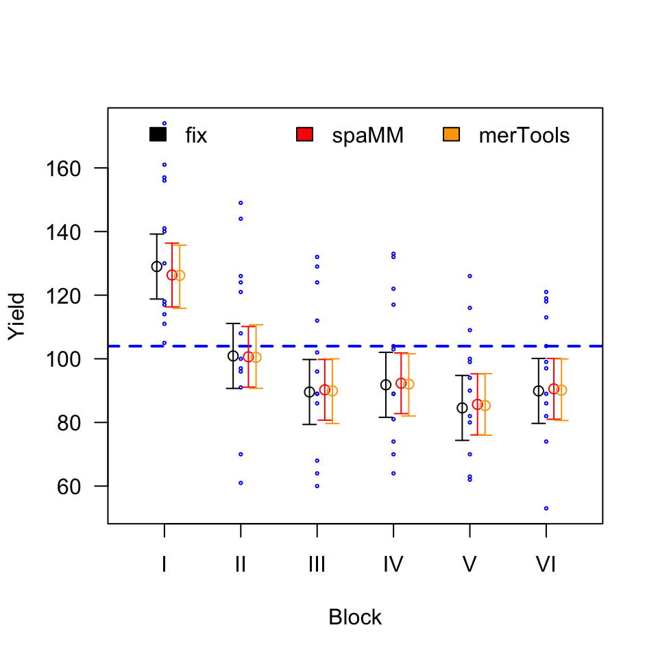

Note: in LMM predictions are attracted toward the mean.

## Comparing predictions from LM and LMM

```r
plot(Oats2$yield ~ unclass(Oats2$Block), axes = FALSE, ylab = "Yield", xlab = "Block",
     xlim = c(0.5, length(levels(Oats2$Block)) + 0.5), col = "blue", cex = 0.3)
abline(h = mean(tapply(Oats2$yield, Oats2$Block, mean)), lty = 2, lwd = 2, col = "blue")
points(p$fit[, "fit"] ~ I(1:length(levels(Oats2$Block))-0.1))
arrows(x0 = (1:length(levels(Oats2$Block))) - 0.1, y0 = p$fit[, "lwr"],
       y1 = p$fit[, "upr"], code = 3, angle = 90, length = 0.05)
points(p3 ~ I(1:length(levels(Oats2$Block)) + 0.1), col = "red")
arrows(x0 = (1:length(levels(Oats2$Block))) + 0.1, y0 = attr(p3, "intervals")[, 1],
       y1 = attr(p3, "intervals")[, 2], code = 3, angle = 90, length = 0.05, col = "red")
points(p4$fit ~ I(1:length(levels(Oats2$Block)) + 0.2), col = "orange")
arrows(x0 = (1:length(levels(Oats2$Block))) + 0.2, y0 = p4$upr,
       y1 = p4$lwr, code = 3, angle = 90, length = 0.05, col = "orange")
axis(1, at = 1:length(levels(Oats2$Block)), labels = levels(Oats2$Block))
axis(2, las = 1)
box()
legend("top", fill = c("black", "red", "orange"), legend = c("fix", "spaMM", "merTools"),
       bty = "n", horiz = TRUE)
```

## Tests

## Testing the effect of `nitro`

### LM

```r
mod_lm_nonitro <- lm(yield ~ Variety + Block, data = Oats2)
anova(mod_lm, mod_lm_nonitro)
```

```
## Analysis of Variance Table
##
## Model 1: yield ~ nitro + Variety + Block
## Model 2: yield ~ Variety + Block
##   Res.Df   RSS Df Sum of Sq     F    Pr(>F)
## 1     63 14788
## 2     64 34324 -1    -19536 83.23 3.968e-13 ***
## ---
## Signif. codes:  0 '***' 0.001 '**' 0.01 '*' 0.05 '.' 0.1 ' ' 1
```

## Testing the effect of `nitro`

### with `lme4` using an asymptotic LRT

```r
mod_lmm_lme4_nitro <-  lmer(yield ~ nitro + Variety + (1|Block), data = Oats2, REML = FALSE)
mod_lmm_lme4_nonitro <-  lmer(yield ~ Variety + (1|Block), data = Oats2, REML = FALSE)
anova(mod_lmm_lme4_nitro, mod_lmm_lme4_nonitro)
```

```
## Data: Oats2
## Models:
## mod_lmm_lme4_nonitro: yield ~ Variety + (1 | Block)
## mod_lmm_lme4_nitro: yield ~ nitro + Variety + (1 | Block)
##                      Df    AIC    BIC  logLik deviance  Chisq Chi Df Pr(>Chisq)
## mod_lmm_lme4_nonitro  5 674.37 685.76 -332.19   664.37
## mod_lmm_lme4_nitro    6 620.80 634.46 -304.40   608.80 55.575      1  8.996e-14 ***
## ---
## Signif. codes:  0 '***' 0.001 '**' 0.01 '*' 0.05 '.' 0.1 ' ' 1
```

Note: always use ML fits for testing fixed effects!

## Testing the reliability of the test of the LRT

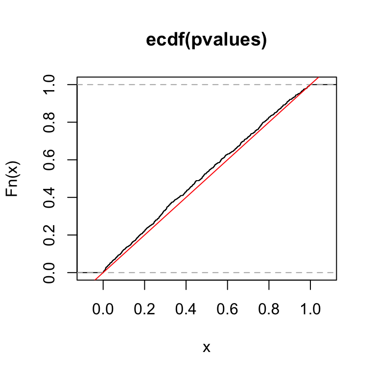

```r
Oats3 <- Oats2
pvalues <- replicate(1000, {
  Oats3$yield <- simulate(mod_lmm_lme4_nonitro)[, 1]
  mod_lmm_lme4_new <- lmer(yield ~ nitro + Variety + (1|Block), data = Oats3, REML = FALSE)
  mod_lmm_lme4_new_nonitro <-  lmer(yield ~ Variety + (1|Block), data = Oats3, REML = FALSE)
  anova(mod_lmm_lme4_new, mod_lmm_lme4_new_nonitro)$"Pr(>Chisq)"[2]})
plot(ecdf(pvalues)); abline(0, 1, col = 2)
```

## Testing the effect of the effect of `nitro`

### with `lme4` + `pbkrtest` using parametric bootstrap

```r
library(pbkrtest)
PBmodcomp(mod_lmm_lme4_nitro, mod_lmm_lme4_nonitro, nsim = 999)
```

```
## Parametric bootstrap test; time: 21.60 sec; samples: 999 extremes: 0;
## large : yield ~ nitro + Variety + (1 | Block)
## small : yield ~ Variety + (1 | Block)
##          stat df   p.value
## LRT    55.575  1 8.993e-14 ***
## PBtest 55.575        0.001 ***
## ---
## Signif. codes:  0 '***' 0.001 '**' 0.01 '*' 0.05 '.' 0.1 ' ' 1
```

## Testing the effect of the effect of `nitro`

### with `spaMM` using an asymptotic LRT

```r
mod_lmm_spaMM_nitro <-  fitme(yield ~ nitro + Variety + (1|Block), data = Oats2, method = "ML")
mod_lmm_spaMM_nonitro <-  fitme(yield ~ Variety + (1|Block), data = Oats2, method = "ML")
anova(mod_lmm_spaMM_nitro, mod_lmm_spaMM_nonitro)
```

```
##      chi2_LR df      p_value
## p_v 55.57491  1 8.992806e-14
```

## Testing the effect of the effect of `nitro`

### with `spaMM` using parametric bootstrap

```r
anova(mod_lmm_spaMM_nitro, mod_lmm_spaMM_nonitro, boot.repl = 999)
```

```
## Bootstrap replicates: bootstrap took 55.2 s.
```

```
##      chi2_LR df      p_value
## p_v 55.57491  1 8.992806e-14
##  ======== Bootstrap: ========
## Raw simulated p-value: 0.001
## Bartlett-corrected LR test:
##      chi2_LR df      p_value
## p_v 55.04624  1 1.176836e-13
```

## The old-fashion `aov()` alternative?

```r
mod_aov <- aov(yield ~ nitro + Variety + Error(Block), data = Oats2)
coef(mod_aov)
```

```
## (Intercept) :
## (Intercept)
##    103.9722
##
## Block :
## numeric(0)
##
## Within :
##             nitro VarietyMarvellous    VarietyVictory
##         73.666667          5.291667         -6.875000
```

The coefficient are the same (except the intercept) because the experimental design is well balanced.

Never use `aov` if this is not the case!

## The old-fashion `aov()` alternative?

```r
summary(mod_aov)
```

```
##
## Error: Block
##           Df Sum Sq Mean Sq F value Pr(>F)
## Residuals  5  15875    3175
##
## Error: Within
##           Df Sum Sq Mean Sq F value   Pr(>F)
## nitro      1  19536   19536  83.230 3.97e-13 ***
## Variety    2   1786     893   3.805   0.0275 *
## Residuals 63  14788     235
## ---
## Signif. codes:  0 '***' 0.001 '**' 0.01 '*' 0.05 '.' 0.1 ' ' 1
```

This test is "not particularly sensible statistically" (as the authors of `?aov` put it)…

## Testing the reliability of the test from `aov()`

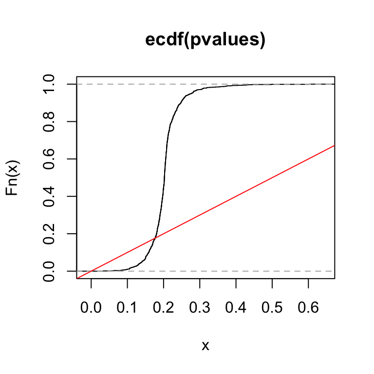

```r
Oats3 <- Oats2
pvalues <- replicate(1000, {
  Oats3$nitro <- runif(1:nrow(Oats3))  ## simulate H0 for nitro effect
  mod_aov_sim <- aov(yield ~ nitro + Variety + Error(Block), data = Oats3)
  summary(mod_aov_sim)[[2]][[1]][2, "Pr(>F)"]
})
plot(ecdf(pvalues))
abline(0, 1, col = 2)
```

## A summary table for mixed models?

Testing estimates of the different levels is not implemented in `lme4` or `spaMM` because the t-test have bad properties for LMM. Some alternatives have been proposed:

```r
library(lmerTest)
mod_lmm_lme4_nitro_bis <-  lmer(yield ~ nitro + Variety + (1|Block), data = Oats2, REML = FALSE)
summary(mod_lmm_lme4_nitro_bis)$coefficients
```

```
##                    Estimate Std. Error       df   t value     Pr(>|t|)
## (Intercept)       82.400000   6.969481 10.38506 11.822975 2.355485e-07
## nitro             73.666667   7.889148 66.00000  9.337721 1.097117e-13
## VarietyMarvellous  5.291667   4.321064 66.00000  1.224621 2.250711e-01
## VarietyVictory    -6.875000   4.321064 66.00000 -1.591043 1.163787e-01
```

## Testing `lme4 + lmerTest` summary table

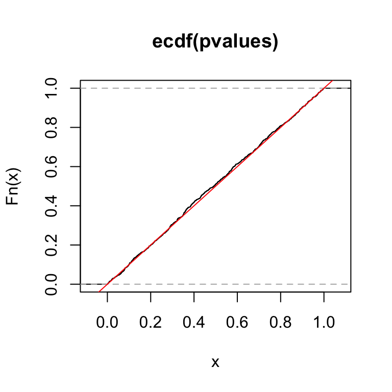

```r
Oats3 <- Oats2
pvalues <- replicate(1000, {
  Oats3$nitro <- runif(1:nrow(Oats3))  ## simulate H0 for nitro effect
  mod_lmm_lme4_nitro_bis <-  lmer(yield ~ nitro + Variety + (1|Block), data = Oats3, REML = FALSE)
  summary(mod_lmm_lme4_nitro_bis)$coefficients[2, "Pr(>|t|)"]
})
plot(ecdf(pvalues))
abline(0, 1, col = 2)
```

## Information Criteria

## Information Criteria

```r
AIC(mod_lm)
```

```
## [1] 607.7199
```

```r
AIC(mod_lmm_lme4)
```

```
## [1] 620.7978
```

```r
print(AIC(mod_lmm_spaMM))
```

```
##        marginal AIC:     conditional AIC:      dispersion AIC:        effective df:
##            620.79777            607.64595            612.79777             63.42341
```

- rely on the marginal AIC if you are interested in marginal predictions.
- rely on the conditional AIC if you are interested in conditional predictions.

## Assumptions

## What are the assumptions in LMM?

- same as LM (except for independence)
- given the fixed effects and the realized values of the random effects, the residuals must be independent
- the random effects must follow the assumed distribution
- the levels of the factorial variable for which random effects are estimated must be representative from the whole population

Note:

- companion packages exist for checking outliers on `lme4` fits: `HLMdiag` and `influence.ME`
- the package `DHARMa` works for `lme4`!
- for now `spaMM` is quite limited in terms of tools to check assumptions

## Plotting residuals

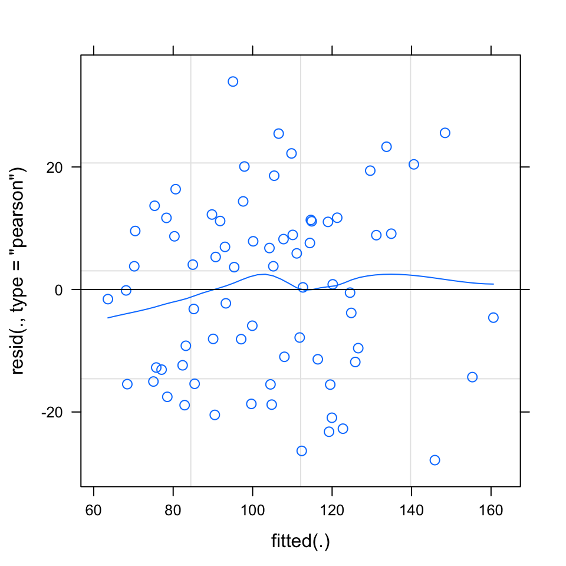

```r
plot(mod_lmm_lme4, type = c("p", "smooth"))  ## see ?lme4:::plot.merMod for details
```

## Plotting residuals

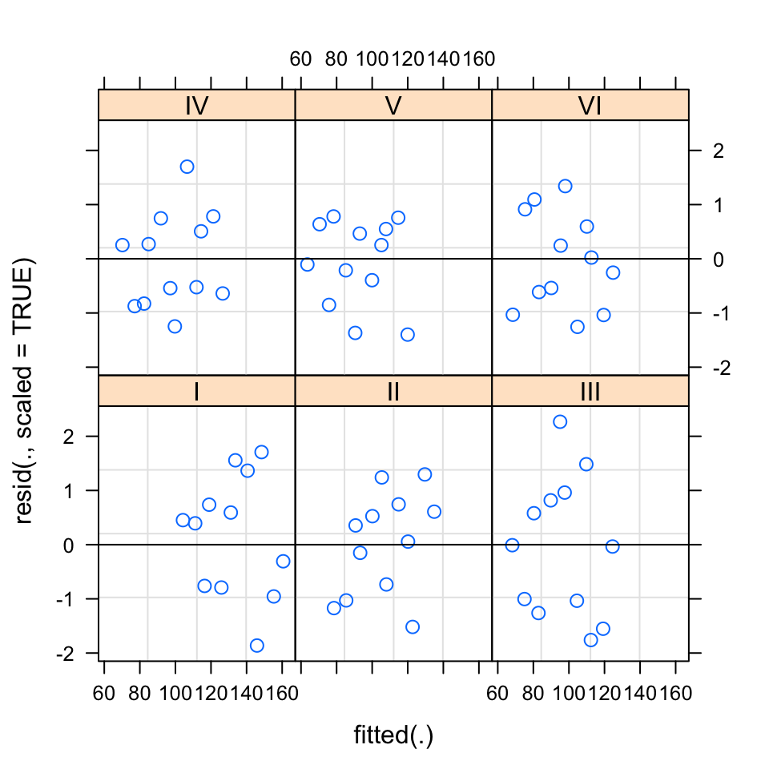

```r
plot(mod_lmm_lme4, resid(., scaled=TRUE) ~ fitted(.) | Block, abline = 0)
```

## Plotting residuals

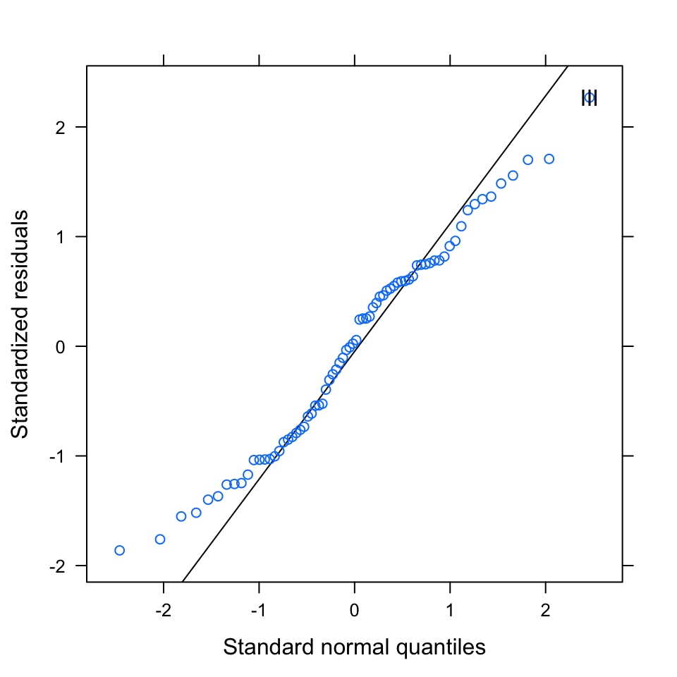

```r
lattice::qqmath(mod_lmm_lme4, id = 0.05) ## id allows to see outliers
```

## Plotting BLUPs

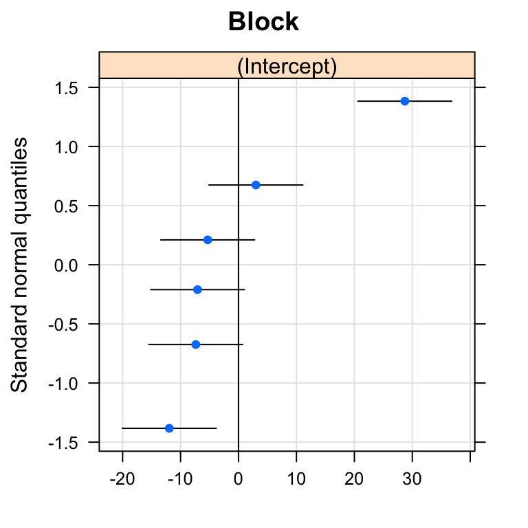

```r
lattice::qqmath(lme4::ranef(mod_lmm_lme4, condVar = TRUE))
```

## Using simulated residuals

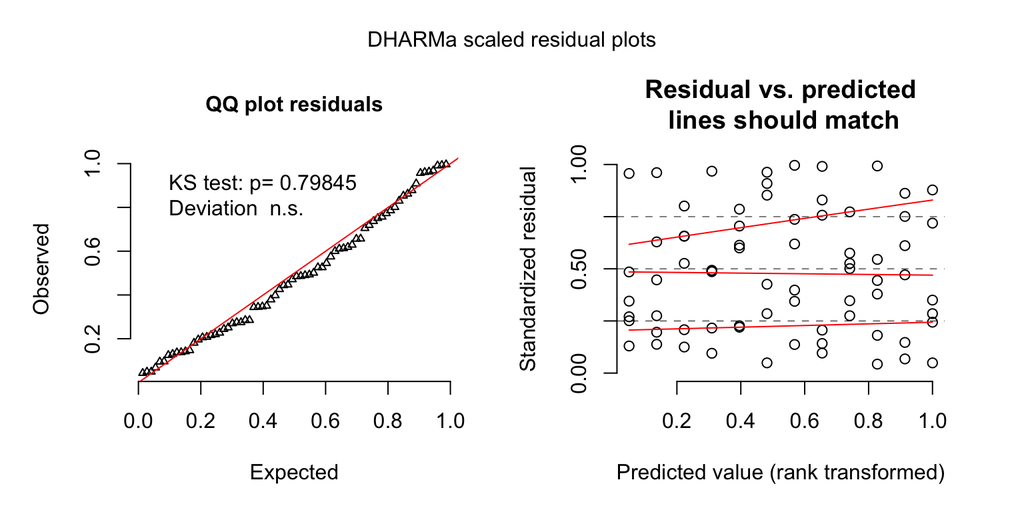

```r
library(DHARMa)
r <- simulateResiduals(mod_lmm_lme4, n = 1000)
plot(r)
```

## Using simulated residuals

### How to deal with random effects matters!

```r
r_unconditional <- simulateResiduals(mod_lmm_lme4, n = 1000)  ## resimulate BLUPs
testTemporalAutocorrelation(r_unconditional, time = 1:nrow(Oats2), plot = FALSE)
```

```
##
##  Durbin-Watson test
##
## data:  simulationOutput$scaledResiduals ~ 1
## DW = 0.9465, p-value = 5.982e-07
## alternative hypothesis: true autocorrelation is greater than 0
```

```r
r_conditional <- simulateResiduals(mod_lmm_lme4, re.form = NULL, n = 1000)  ## conditional to fitted BLUPs
testTemporalAutocorrelation(r_conditional, time = 1:nrow(Oats2), plot = FALSE)
```

```
##
##  Durbin-Watson test
##
## data:  simulationOutput$scaledResiduals ~ 1
## DW = 1.6931, p-value = 0.09426
## alternative hypothesis: true autocorrelation is greater than 0
```

## What you need to remember

- why you may need linear mixed-effects models
- what mixed models are
- how to use `lme4` and/or `spaMM` to fit mixed models
- what BLUPs are
- how to make predictions at two different levels
- how to test effects using parametric bootstraps
- how to check assumptions for a linear mixed-effects model

## Table of contents

## Mixed-effects models

- 4.0 Introduction to LMM
- 4.1 Random effects
- 4.2 Solving LM problems using LMM
- 4.3 A showcase of some useful applications
- 4.4 Introduction to GLMM
- 4.5 More complex mixed models